# Analiza przeżycia

Tomasz Przechlewski

Powiślańska Szkoła Wyższa (Kwidzyn/Poland)  
t.plata-przechlewski@psw.kwidzyn.edu.pl

21/2/2026

## Podstawowe pojęcia

Badany jest **czas** jaki upłynął od początku obserwacji do wystąpienia określonego zdarzenia (np. śmierci, awarii urządzenia, powrotu choroby). Obserwowanych jest $n$ jednostek, w pewnym przedziale czasu (a nie w nieskończoność.)

W związku z tym dane mogą zawierać **obserwacje cenzorowane** albo ucięte (censored). Obserwacje mogą być ucięte **przedwcześnie** wtedy kiedy jednostka z jakiś powodów nie może być dalej obserwowana lub też punktem ucięcia może być zakończenie badania, przed zaobserwowaniem **określonego zdarzenia**

Jeżeli obserwowany jest czas od diagnozy do śmierci spowodowanej przez pewien rodzaj nowotworu to część pacjentów może dalej żyć w momencie zakończenia badania a część może umrzeć z innych przyczyn lub stracono z nimi kontakt (leczą się gdzie indziej.)

Przykładowo obserwowano przez 150 tygodni (czas) siedmiu takich pacjentów:

| numer | czas | zdarzenie | typ |
| --- | --- | --- | --- |
| 1 | 44 | zmarł | n |
| 2 | 65 | zmarł | n |
| 3 | 145 | żyje | c |
| 4 | 30 | zmarł | n |
| 5 | 60 | żyje | c |
| 6 | 125 | zmarł | n |
| 7 | 150 | żyje | c |

Kolumna „typ” oznacza rodzaj obserwacji: uciętą (c) oraz nieuciętą (n). Obserwacje 1, 2, 4 oraz 6 zakończyły się zdarzeniem, dlatego są nieucięte. Pacjenci 3 oraz 5 byli obserwowani odpowiednio przez 145 i 60 tygodni, po czym utracono z nimi kontakt. Pacjent numer 7 był ciągle żywy w momencie zakończenia badania.

Obecność **obserwacji cenzorowanych** jest specyficzna dla metod opracowanych w kontekście analizy przeżycia.

Czas do zdarzenia jest zmienną losową. Można ją opisywać w sposób klasyczny — za pomocą dystrybuanty lub funkcji gęstości — częściej jednak korzysta się z alternatywnych narzędzi: **funkcji przeżycia** oraz **funkcji hazardu**.

**Funkcja przeżycia** (*survival function*): prawdopodobieństwo przeżycia w czasie dłuższym niż $t$

$$S(t)=P(T>t)$$

**Funkcja hazardu** (albo współczynnik hazardu, bo ta funkcja to współczynnik) definiuje **natychmiastowe** (w nieskończenie małym przedziale) ryzyko zajścia zdarzenia w czasie $t$, przy założeniu, że jednostka przetrwała do tego momentu

$$\begin{equation}
h(t) = \lim_{\Delta t \to 0} \frac{P \left( t \leq T < t + \Delta t
\vert T \geq t \right)}{\Delta t}
\end{equation}$$

Funkcję hazardu można interpretować jako **oczekiwaną liczbę zdarzeń na jednostkę badaną w jednostce czasu** ($\Delta t =1$):

$$\begin{equation}
h(t) = P ( t \leq T < t + 1 \vert T \geq t )
\end{equation}$$

Jeśli funkcja hazardu dla zgonu w pewnej grupie ludzi wynosi 0,05 jednostki/rok, oznacza to, oczekujemy 0,05 zgonu rocznie. Jeżeli ludzi w grupie jest $n$, oczekujemy $0,05 \times n$ zgonów rocznie (założyliśmy $\Delta=1$ rok). Należy pamiętać, że prawdziwa funkcja hazardu opisuje ryzyko chwilowe, definiowane w granicy $Δt→0$

**Skumulowana funkcja hazardu**

Funkcja hazardu jest nieujemna.

Suma hazardu od $0$ do $t$ to skumulowana funkcja hazardu. Ponieważ $t$ jest zmienną ciągłą, definiuje się ją formalnie jako całkę oznaczoną:

$$\begin{equation}
H(t) = \int_0^t h(u)du
\end{equation}$$

Skumulowana funkcja hazardu $H(t)$ opisuje skumulowaną intensywność ryzyka zdarzenia do czasu $t$ i jest powiązana z prawdopodobieństwem przeżycia poprzez zależność $S(t)=\exp(−H(t))$.

## Estymator Kaplana–Meiera

Estymator Kaplana–Meiera jest estymatorem funkcji przeżycia $S(t)$ postaci:

$$\hat S(t)=∏_{ t_i ≤t}( 1− \frac{d_i}{n_i})$$

gdzie: $t_i$ – kolejne czasy zdarzeń; $d_i$ – liczba zdarzeń w czasie $t_i$; $n_i$ – liczba osób „narażonych” w czasie $t_i$.

$p_i = 1 - d_i/n_i$ to warunkowe prawdopodobieństwo przeżycia w czasie $i$; (warunkowe tzn. liczone dla tych pacjentów, którzy dożyli czasu $i-1$)

Przykładowo: jeżeli obserwujemy grupę pacjentów SOR przez trzy dni, to $p_1$ oznacza prawdopodobieństwo przeżycia pierwszego dnia, $p_2$ – prawdopodobieństwo przeżycia drugiego dnia a $p_3$ – prawdopodobieństwo przeżycia trzeciego dnia

$$S(3) = p_1 \cdot p_2 \cdot
p_3$$

oznacza prawdopodobieństwo przeżycia w czasie dłuższym niż $t=3$ czyli mówiąc po polsku przeżycia co najmniej trzech dni.

Oceny wartości estymatora Kaplana–Meiera można przedstawić w tabeli, jednak zwykle prezentuje się je w postaci wykresu (krzywej Kaplana–Meiera).

### Przykład (NCCTG Lung Cancer Data)

Dane pochodzą z badania klinicznego dotyczącego pacjentów z rakiem płuca, prowadzonego przez North Central Cancer Treatment Group (NCCTG). Dane pochodzą z pakietu `survival` (R) i są dostępne w pliku `lung.csv`.

Zbiór zawiera informacje o pacjentach oraz ich czasie przeżycia po diagnozie i leczeniu.

`time` – czas przeżycia (w dniach) od momentu włączenia do badania (postawienia diagnozy?)

`status` – status pacjenta: 1 = cenzurowany (pacjent żył w momencie zakończenia obserwacji) 2 = zgon

`age` – wiek pacjenta

`sex` – płeć (1 = mężczyzna, 2 = kobieta)

`ph.ecog` – ocena sprawności pacjenta (ECOG performance status)

`ph.karno` – wskaźnik Karnofsky’ego (stan ogólny)

`pat.karno` – wskaźnik Karnofsky’ego oceniony przez pacjenta

`wt.loss` – utrata masy ciała (funty)

`meal.cal` – dzienne spożycie kalorii (szacowane)

Pierwsze sześć wierszy pliku `lung.csv` wyglądają tak:

```
##   inst time status age sex ph.ecog ph.karno pat.karno meal.cal wt.loss
## 1    3  306      2  74   1       1       90       100     1175      NA
## 2    3  455      2  68   1       0       90        90     1225      15
## 3    3 1010      1  56   1       0       90        90       NA      15
## 4    5  210      2  57   1       1       90        60     1150      11
## 5    1  883      2  60   1       0      100        90       NA       0
## 6   12 1022      1  74   1       1       50        80      513       0
```

Oceny wartości estymatora Kaplana–Meiera (6 pierwszych wierszy + “…” + 3 ostatnie) oraz krzywa Kaplana-Meiera

```
## Call: survfit(formula = s ~ 1, data = lung)
##
##  time n.risk n.event survival std.err lower 95% CI upper 95% CI
##     5    228       1   0.9956 0.00438       0.9871        1.000
##    11    227       3   0.9825 0.00869       0.9656        1.000
##    12    224       1   0.9781 0.00970       0.9592        0.997
##    13    223       2   0.9693 0.01142       0.9472        0.992
##    15    221       1   0.9649 0.01219       0.9413        0.989
##    26    220       1   0.9605 0.01290       0.9356        0.986
## ...
##   791      9       1   0.0783 0.02462       0.0423        0.145
##   814      7       1   0.0671 0.02351       0.0338        0.133
##   883      4       1   0.0503 0.02285       0.0207        0.123
```

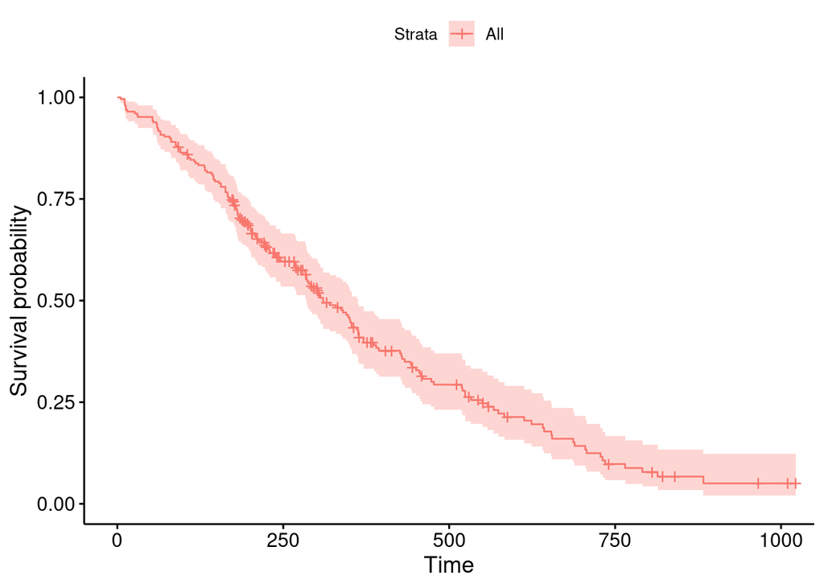

Kolumna `survival` to estymowane prawdopodobieństwo przeżycia co najmniej `time` dni. Ostatnia obserwacja (883 dzień) zawiera 4 żyjących pacjentów z których 1 zmarł. Po zakończeniu badania mamay ciągle trzech żywych, zatem ostatnia ocena $S(t)$ jest większa od zera, bo nie wiemy co będzie później…

Krzywą Kaplana–Meiera można wykreślić osobno dla każdej grupy wyznaczonej przez wartości zmiennej nominalnej. Taką zmienną w zbiorze *NCCTG Lung Cancer Data* jest płeć (`sex`)

```
## Call: survfit(formula = Surv(time, status) ~ sex, data = lung)
##
##                 sex=1
##  time n.risk n.event survival std.err lower 95% CI upper 95% CI
##    11    138       3   0.9783  0.0124       0.9542        1.000
##    12    135       1   0.9710  0.0143       0.9434        0.999
##    13    134       2   0.9565  0.0174       0.9231        0.991
##    15    132       1   0.9493  0.0187       0.9134        0.987
##    26    131       1   0.9420  0.0199       0.9038        0.982
## ...
##   735      5       1   0.1248  0.0549       0.0527        0.295
##   765      3       1   0.0832  0.0499       0.0257        0.270
```

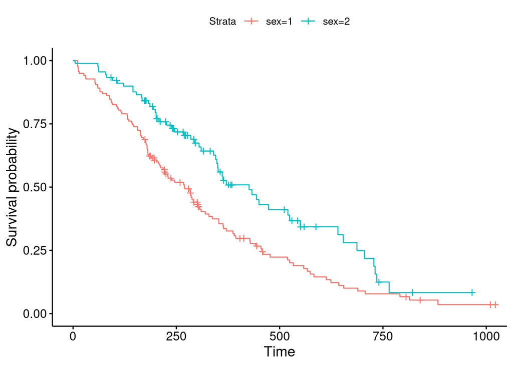

Można na oko porówać krzywe albo zastosować test Mantela-Heanszela, określany także jako test log-rank. Hipotezą zerową w tym teście jest równość wszystkich porównywanych krzywych przeżycia. Hipoteza alternatywna w tej sytuacji zakłada że co najmniej jedna krzywa się istotnie różni.

```
## Call:
## survdiff(formula = s ~ sex, data = lung, rho = 0)
##
##         N Observed Expected (O-E)^2/E (O-E)^2/V
## sex=1 138      112     91.6      4.55      10.3
## sex=2  90       53     73.4      5.68      10.3
##
##  Chisq= 10.3  on 1 degrees of freedom, p= 0.001
```

Niska wartość $p$ równa 0.001 wskazuje, że należy odrzucić hipotezę zerową o identyczności funkcji przeżycia w populacjach kobiet i mężczyzn. Oznacza to, że funkcje te różnią się istotnie statystycznie.

## Regresja Coxa

Analiza z użyciem estymatora Kaplana-Meiera pozwala na porównanie krzywych przeżycia, nie pozwala na objaśnienie od czego zależy prawdopodobieństwo przeżycia. To umożliwia model proporcjonalnych hazardów Coxa, który ma postać:

$$h(t, X) = h_0(t) \exp(X\beta)$$
gdzie: $h(t, X)$ funkcja hazardu, zależna od czasu oraz $X$; $h_0(t)$ zerowa linia hazardu, której wartości nie zależą od $X$ a tylko od $t$, co odpowiada sytuacji kiedy gdy wszystkie zmienne $X$ są równe zero; $X$ – wektor zmiennych (niezależnych) wpływających na funkcję hazardu; $\beta$ – współczynniki modelu.

Jeżeli ograniczymy się do przykładu w którym po prawej stronie występuje tylko jedna zmienna X, która może przyjąć dwie wartości 0 oraz 1 (zmienna binarna), wtedy:

$$\begin{align}
h_0(t, X=0) = h_0(t) \\
h_1(t, X=1) = h_0(t) \exp(X\beta)
\end{align}$$

stąd

$$\textrm{HR}(t) = \frac{h_0(t) \exp(X\beta)}{ h_0(t) } = \exp(X\beta)$$

$\textrm{HR}(t)$ to iloraz hazardów. Wynosi on $e^{β_1}$ i pozostaje stały w czasie $t$ (stąd nazwa: regresja proporcjonalnych hazardów). Krzywe hazardu mogą się zmieniać w czasie, ale zawsze są skalowane względem siebie tym samym czynnikiem. Jeżeli X=1 oznacza kobietę a X=0 mężczyznę, to krzywe hazardu kobiet względem mężczyn są do siebie równoległe, albo HR nie zmienia się w czasie. Tak może być lub nie. W regresji Coxa zakładamy że tak jest, co pozwala oszacować model bez znajomości konkretnej postaci krzywej hazardu bazowego.

Interpretacja: $HR > 1$ większe ryzyko zdarzenia; $HR < 1$ mniejsze ryzyko; $HR = 1$ brak wpływu.

Wynik można uogólnić dla przypadku kiedy $X$ jest wektorem zmniennych niekoniecznie binarnych. Jeżeli $X_i$ jest zmienną ciągłą i jej wartość wzrośnie o jednostkę to hazard zmieni się o $(e^{\beta_i} − 1) \times 100$%, przy założeniu że pozostałe zmienne $X$ mają ustalone wartości.

Ocena dopasowania modelu:

Czy różnica pomiędzy modelem badanym a bazowym (pustym) jest istotna? Sprawdza się to za pomocą testu ilorazu wiarygodności (*likelihood ratio test*)

Czy oceny poszczególnych parametrów są istotnie różne od zera

Współczynniki pseudo-$R^2$

### Przykład

Hipoteza badawcza: Płeć i wiek mają istotny wpływ na hazard (ryzyko zdarzenia) w czasie.

```
## Call:
## coxph(formula = Surv(time, status) ~ sex + age, data = lung)
##
##   n= 228, number of events= 165
##
##          coef exp(coef)  se(coef)      z Pr(>|z|)
## sex -0.513219  0.598566  0.167458 -3.065  0.00218 **
## age  0.017045  1.017191  0.009223  1.848  0.06459 .
## ---
## Signif. codes:  0 '***' 0.001 '**' 0.01 '*' 0.05 '.' 0.1 ' ' 1
##
##     exp(coef) exp(-coef) lower .95 upper .95
## sex    0.5986     1.6707    0.4311    0.8311
## age    1.0172     0.9831    0.9990    1.0357
##
## Concordance= 0.603  (se = 0.025 )
## Likelihood ratio test= 14.12  on 2 df,   p=0.0009
## Wald test            = 13.47  on 2 df,   p=0.001
## Score (logrank) test = 13.72  on 2 df,   p=0.001
```

Współczynnik $\beta_{sex} = -0.513219$ jest istotny na poziomie 0,05 (wartość $p$ jest równa 0.00218). Ponieważ mężczyna = 1 a kobieta = 2, zatem kobiety mają o 40.1434% mniejsze ryzyko zgonu niż mężczyźni.

Współczynnik $\beta_{age} = 0.017045$ nie jest istotny na poziomie 0,05 (wartość $p$ jest równa 0.06459). Gdyby był to byśmy powiedzieli że każdy dodatkowy rok wieku zwiększa o 1.7191% ryzyko zgonu.

Model jest istotnie różny od modelu bazowego (`p=0.0009`).

## Framingham Heart Study

Zbiór ten opisano w materiałach dotyczących regresji i korelacji.

Przypominam, że: `TIMECVD` to number of days from Baseline exam to first CVD event during followup or Number of days from Baseline to censor date.

```
## Call:
## coxph(formula = Surv(TIMECVD, CVD) ~ AGE + CURSMOKE + SYSBP,
##     data = f0)
##
##   n= 4434, number of events= 1157
##
##              coef exp(coef) se(coef)      z             Pr(>|z|)
## AGE      0.059365  1.061162 0.003894 15.244 < 0.0000000000000002 ***
## CURSMOKE 0.471372  1.602190 0.060693  7.767  0.00000000000000807 ***
## SYSBP    0.016210  1.016342 0.001229 13.188 < 0.0000000000000002 ***
## ---
## Signif. codes:  0 '***' 0.001 '**' 0.01 '*' 0.05 '.' 0.1 ' ' 1
##
##          exp(coef) exp(-coef) lower .95 upper .95
## AGE          1.061     0.9424     1.053     1.069
## CURSMOKE     1.602     0.6241     1.423     1.805
## SYSBP        1.016     0.9839     1.014     1.019
##
## Concordance= 0.703  (se = 0.007 )
## Likelihood ratio test= 597.6  on 3 df,   p=<0.0000000000000002
## Wald test            = 622.2  on 3 df,   p=<0.0000000000000002
## Score (logrank) test = 653.8  on 3 df,   p=<0.0000000000000002
```